# FAQ

## Can index X be added to the package?

Adding new segregation indices is not a big trouble. Please [open an issue](https://github.com/elbersb/segregation/issues) on GitHub to request an index to be added.

## How can I compute indices for different areas at once?

If you use the `dplyr` package, one pattern that works well is to use `group_modify`. Here, we compute the pairwise Black-White dissimilarity index for each state separately:

```r
library("segregation")
library("dplyr")

schools00 %>%
  filter(race %in% c("black", "white")) %>%
  group_by(state) %>%
  group_modify(~ dissimilarity(
    data = .x,
    group = "race",
    unit = "school",
    weight = "n"
  ))
```

```
#> # A tibble: 3 × 3
#> # Groups:   state [3]
#>   state stat    est
#>   <fct> <chr> <dbl>
#> 1 A     D     0.706
#> 2 B     D     0.655
#> 3 C     D     0.704
```

A similar pattern works also well with `data.table`:

```r
library("data.table")

schools00 <- as.data.table(schools00)
schools00[
  race %in% c("black", "white"),
  dissimilarity(data = .SD, group = "race", unit = "school", weight = "n"),
  by = .(state)
]
```

```
#>     state   stat       est
#>    <fctr> <char>     <num>
#> 1:      A      D 0.7063595
#> 2:      B      D 0.6548485
#> 3:      C      D 0.7042057
```

To compute many decompositions at once, it’s easiest to combine the data for the two time points. For instance, here’s a `dplyr` solution to decompose the state-specific M indices between 2000 and 2005:

```r
# helper function for decomposition
diff <- function(df, group) {
  data1 <- filter(df, year == 2000)
  data2 <- filter(df, year == 2005)
  mutual_difference(data1, data2, group = "race", unit = "school", weight = "n")
}

# add year indicators
schools00$year <- 2000
schools05$year <- 2005
combine <- bind_rows(schools00, schools05)

combine %>%
  group_by(state) %>%
  group_modify(diff) %>%
  head(5)
```

```
#> # A tibble: 5 × 3
#> # Groups:   state [1]
#>   state stat          est
#>   <fct> <chr>       <dbl>
#> 1 A     M1         0.409
#> 2 A     M2         0.445
#> 3 A     diff       0.0359
#> 4 A     additions -0.0159
#> 5 A     removals   0.0390
```

Again, here’s also a `data.table` solution:

```r
setDT(combine)
combine[, diff(.SD), by = .(state)] %>% head(5)
```

```
#>     state      stat         est
#>    <fctr>    <char>       <num>
#> 1:      A        M1  0.40859652
#> 2:      A        M2  0.44454379
#> 3:      A      diff  0.03594727
#> 4:      A additions -0.01585879
#> 5:      A  removals  0.03903106
```

## How can I use Census data from `tidycensus` to compute segregation indices?

Here are a few examples thanks to [Kyle Walker](https://twitter.com/kyle_e_walker/status/1392188844724809728), the author of the [tidycensus](https://walker-data.com/tidycensus/articles/basic-usage.html) package.

First, download the data:

```r
library("tidycensus")

cook_data <- get_acs(
  geography = "tract",
  variables = c(
    white = "B03002_003",
    black = "B03002_004",
    asian = "B03002_006",
    hispanic = "B03002_012"
  ),
  state = "IL",
  county = "Cook"
)
```

Because this data is in “long” format, it’s easy to compute segregation indices:

```r
# compute index of dissimilarity
cook_data %>%
  filter(variable %in% c("black", "white")) %>%
  dissimilarity(
    group = "variable",
    unit = "GEOID",
    weight = "estimate"
  )
```

```
#>      stat       est
#>    <char>     <num>
#> 1:      D 0.7855711
```

```r
# compute multigroup M/H indices
cook_data %>%
  mutual_total(
    group = "variable",
    unit = "GEOID",
    weight = "estimate"
  )
```

```
#>      stat       est
#>    <char>     <num>
#> 1:      M 0.5114435
#> 2:      H 0.4089561
```

Producing a map of local segregation scores is also not hard:

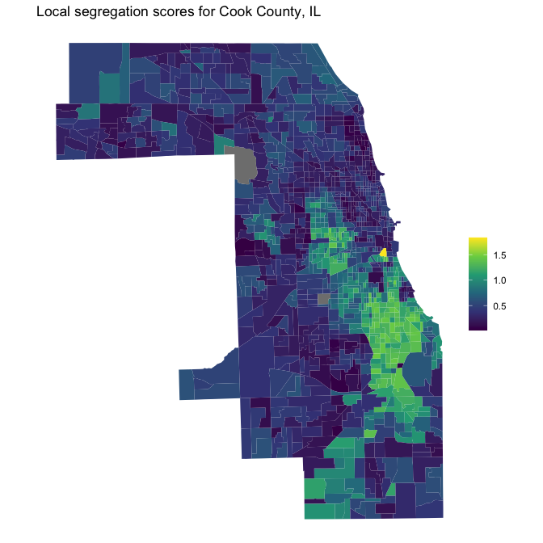

```r
library("tigris")
library("ggplot2")

local_seg <- mutual_local(cook_data,
  group = "variable",
  unit = "GEOID",
  weight = "estimate",
  wide = TRUE
)

# download shapefile
seg_geom <- tracts("IL", "Cook", cb = TRUE, progress_bar = FALSE) %>%
  left_join(local_seg, by = "GEOID")
ggplot(seg_geom, aes(fill = ls)) +
  geom_sf(color = NA) +
  coord_sf(crs = 3435) +
  scale_fill_viridis_c() +
  theme_void() +
  labs(
    title = "Local segregation scores for Cook County, IL",
    fill = NULL
  )
```

## How can I compute margins-adjusted local segregation scores?

When using `mutual_difference`, supply `method = "shapley_detailed"` to get two different local segregation scores that are margins-adjusted (one is coming from adjusting forward, the other from adjusting backwards). By averaging them we can create a single margins-adjusted local segregation score:

```r
diff <- mutual_difference(schools00, schools05, "race", "school",
  weight = "n", method = "shapley_detailed"
)

diff[stat %in% c("ls_diff1", "ls_diff2"),
  .(ls_diff_adjusted = mean(est)),
  by = .(school)
]
```

```
#>       school ls_diff_adjusted
#>       <fctr>            <num>
#>    1:   A1_3     -0.088983164
#>    2:   A2_2     -0.044338042
#>    3:   A2_3     -0.101696519
#>    4:   A2_4     -0.020134162
#>    5:   A2_6     -0.138567163
#>   ---
#> 1706: C164_2     -0.031329845
#> 1707: C165_1     -0.023978101
#> 1708: C165_3      0.003781632
#> 1709: C166_1      0.010270713
#> 1710: C167_1     -0.002663687
```